# Part 8 Appendix

Sample description, full regression results, supplementary figures

Author

Lara Mazzarelli

## Role in the pipeline

| **Thesis section** | Appendix |
| --- | --- |
| **Previous file** | `07_robustness_checks.qmd` |

| Robustness check | What it is | Filter / change vs. main specification |
| --- | --- | --- |
| R1 | without country x year FE | `fe` drops `country^fyear` |
| R2 | without industry x year FE | `fe` drops `sic2^fyear` |
| R3 | without firm FE | `fe` drops `gvkey` |
| R4 | without control variables | `ctrl = NULL` |
| R5 | firm-specific linear trend | `fe` adds `gvkey[t_c]` |
| R6 | one-year growth horizon | `y = "growth_f1_w"` |
| R7 | alliance window (year t / 2y / 4y / 5y) | alliance counts use a different window suffix |
| R8 | placebo: growth t-6 to t-3 | `y` = placebo growth, no `growth_l1_w` control |
| R9 | excluding SDC coverage gap 2009-2015 | `data = d[!(fyear %between% c(2009, 2015))]` |
| R10 | revenue floor: USD 20m / no floor | `data = d[revt_usd_lag >= 20]` or `d_nofloor` |
| R11 | United States / non-United States firms | `data = d[country == "USA"]` / `d[country != "USA"]` |
| R12 | below- / above-median firm size | `data = d[ln_at_usd <= med_size]` / `d[ln_at_usd > med_size]` |

## Setup

```r
source("00_config.R")
library(data.table)
library(fixest)
library(ggplot2)
library(patchwork)
library(countrycode)
library(scales)

out <- file.path(path, "appendix_out_v2")

unlink(out, recursive = TRUE)
dir.create(out)

d  <- readRDS(file.path(path, "analysis_sample.rds"))
fp <- readRDS(file.path(path, "firmyear_panel.rds"))
af <- readRDS(file.path(path, "alliances_focal.rds"))
d[, sic2 := as.factor(sic2)]

# alliance-firm observations inside the analysis sample (same construction as 05)
af_s <- af[d[, .(gvkey, fyear)], on = .(gvkey, year = fyear), nomatch = 0]

c(firm_years = nrow(d), firms = uniqueN(d$gvkey), countries = uniqueN(d$country),
  alliance_firm_obs = nrow(af_s))
```

```
       firm_years             firms         countries alliance_firm_obs
           461882             43407               124             51563
```

```r
wins <- function(x, p = 0.01) {
  q <- quantile(x, c(p, 1 - p), na.rm = TRUE)
  pmin(pmax(x, q[1]), q[2])
}
diff_test <- function(m, a, b) {
  v   <- vcov(m)
  est <- coef(m)[[a]] - coef(m)[[b]]
  se  <- sqrt(v[a, a] + v[b, b] - 2 * v[a, b])
  c(est = est, se = se, t = est / se, p = 2 * pnorm(-abs(est / se)))
}
joint_p <- function(m, pattern = "^log1p\\(d") wald(m, keep = pattern, print = FALSE)$p
omnibus_p <- function(m, pattern = "^log1p\\(d") {
  nm <- grep(pattern, names(coef(m)), value = TRUE)
  R <- matrix(0, nrow = 4, ncol = 5)
  for (i in 1:4) { R[i, i] <- 1; R[i, i + 1] <- -1 }
  rb   <- R %*% coef(m)[nm]
  stat <- as.numeric(t(rb) %*% solve(R %*% vcov(m)[nm, nm] %*% t(R)) %*% rb)
  pchisq(stat, df = 4, lower.tail = FALSE)
}

controls <- "ln_at_usd + roa_w + leverage_w + growth_l1_w"
fe_main  <- "gvkey + sic2^fyear + country^fyear"

est <- function(rhs, fe = fe_main, y = "growth_f3_w", data = d, ctrl = controls) {
  rhs_all <- if (is.null(ctrl)) rhs else paste(rhs, "+", ctrl)
  feols(as.formula(paste0(y, " ~ ", rhs_all, " | ", fe)), data = data, cluster = ~gvkey)
}

rhs_h1   <- "log1p(n_rel_3y) + log1p(n_unrel_3y)"
rhs_dist <- function(suffix) paste0("log1p(", cats, suffix, ")", collapse = " + ")
rhs_h2   <- rhs_dist("_3y")
rhs_h3   <- paste("log1p(n_rel_eq_3y) + log1p(n_rel_ne_3y)",
                  "log1p(n_unrel_eq_3y) + log1p(n_unrel_ne_3y)", sep = " + ")
rhs_h4   <- paste0(c(rbind(paste0("log1p(", cats, "_eq_3y)"), paste0("log1p(", cats, "_ne_3y)"))),
                   collapse = " + ")

# exact row labels as they appear in the thesis (Tables 1, 8-11)
cat_labels_paper <- c(d0_same4 = "D0 (same four-digit SIC)", d1_same3 = "D1 (same three-digit SIC)",
                      d2_same2 = "D2 (same major group)", d3_same_division = "D3 (same SIC division)",
                      d4_diff_division = "D4 (different SIC division)")

# The "no revenue floor" version of the sample (same filters as the main sample,
# minus the revt_usd_lag >= 10 step) -- needed both for the R10 robustness model
# (Appendix B) and to show, descriptively, what the revenue floor is cutting
# (Appendix A, Figure A8). Rebuilt from the raw panel because the alliance-window
# variables have to be recomputed before the floor is applied (see 07, Panel E).
fp_raw <- copy(fp)
fp_raw[, fyear3 := fyear + 3L]
fp_raw[fp_raw, on = .(gvkey, fyear3 = fyear), `:=`(revt_f3 = i.revt, curcd_f3 = i.curcd)]
fp_raw[, growth_f3 := fifelse(revt > 0 & revt_f3 > 0 & curcd == curcd_f3, (revt_f3 / revt)^(1/3) - 1, NA_real_)]
fp_raw[, `:=`(growth_f3_w = wins(growth_f3), growth_l1_w = wins(growth_l1), roa_w = wins(roa), leverage_w = wins(leverage))]
for (k in cats) fp_raw[, (k) := get(paste0(k, "_eq")) + get(paste0(k, "_ne"))]
setorder(fp_raw, gvkey, fyear)
fp_raw[, `:=`(fy_m1 = fyear - 1L, fy_m2 = fyear - 2L)]
for (v in cats) {
  src <- fp_raw[, .(gvkey, fyear, val = get(v))]
  fp_raw[src, on = .(gvkey, fy_m1 = fyear), m1 := i.val]
  fp_raw[src, on = .(gvkey, fy_m2 = fyear), m2 := i.val]
  fp_raw[, (paste0(v, "_3y")) := get(v) + fcoalesce(m1, 0L) + fcoalesce(m2, 0L)]
  fp_raw[, c("m1", "m2") := NULL]
}
d_nofloor <- fp_raw[!(financial %in% TRUE)]
d_nofloor <- d_nofloor[!is.na(sic2) & !(as.integer(as.character(sic2)) %in% c(49, 99))]
d_nofloor <- d_nofloor[!is.na(growth_f3_w) & !is.na(ln_at_usd) & !is.na(roa) & !is.na(leverage) & !is.na(growth_l1)]
d_nofloor[, sic2 := as.factor(sic2)]
cat("no-floor sample:", nrow(d_nofloor), " | main sample (floor = USD 10m):", nrow(d), "\n")
```

```
no-floor sample: 539485  | main sample (floor = USD 10m): 461882
```

# Appendix A: Sample Description

This section describes the analysis sample by country, region, firm size and time.

## A1. Firm-years and firms by country

```r
by_country <- d[, .(firm_years = .N, firms = uniqueN(gvkey)), by = country][order(-firm_years)]
by_country[, `:=`(share_firm_years_pct = round(100 * firm_years / sum(firm_years), 1))]

top_n <- 15
tabA1 <- rbind(
  by_country[1:top_n],
  by_country[(top_n + 1):.N, .(country = "Other", firm_years = sum(firm_years),
                                firms = sum(firms), share_firm_years_pct = round(100 * sum(firm_years) / sum(by_country$firm_years), 1))])
knitr::kable(tabA1, format.args = list(big.mark = ","),
             caption = "Table A1: Firm-years and firms by country (top 15, Compustat country of incorporation/location)")
```

Table A1: Firm-years and firms by country (top 15, Compustat country of incorporation/location)

| country | firm_years | firms | share_firm_years_pct |
| --- | --- | --- | --- |
| USA | 88,524 | 9,078 | 19.2 |
| JPN | 59,872 | 4,085 | 13.0 |
| CHN | 52,411 | 5,064 | 11.3 |
| IND | 31,380 | 2,860 | 6.8 |
| TWN | 24,723 | 2,021 | 5.4 |
| GBR | 19,186 | 1,956 | 4.2 |
| KOR | 15,993 | 1,718 | 3.5 |
| HKG | 14,963 | 1,323 | 3.2 |
| MYS | 13,648 | 1,095 | 3.0 |
| CAN | 9,955 | 1,133 | 2.2 |
| AUS | 8,760 | 1,064 | 1.9 |
| SGP | 8,352 | 745 | 1.8 |
| THA | 8,300 | 668 | 1.8 |
| FRA | 8,282 | 785 | 1.8 |
| DEU | 7,595 | 713 | 1.6 |
| Other | 89,938 | 9,105 | 19.5 |

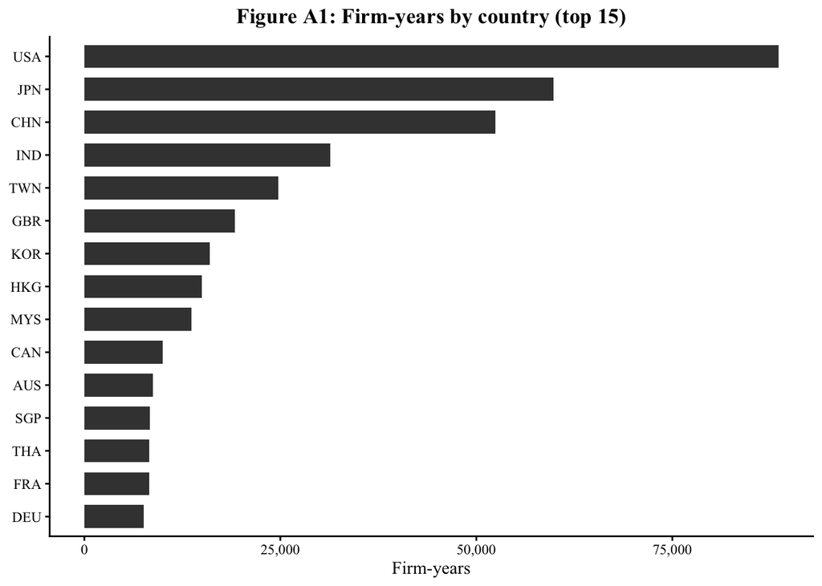

```r
fwrite(tabA1, file.path(out, "table_appx_A1_country.csv"))
fwrite(by_country, file.path(out, "table_appx_A1_country_full.csv"))  # ungrouped, for your own checking

p_A1 <- ggplot(tabA1[country != "Other"], aes(x = reorder(country, firm_years), y = firm_years)) +
  geom_col(fill = "grey25", width = 0.7) +
  coord_flip() +
  scale_y_continuous(labels = scales::comma) +
  labs(x = NULL, y = "Firm-years", title = "Figure A1: Firm-years by country (top 15)") +
  theme_thesis()
p_A1
```

```r
ggsave(file.path(out, "fig_appx_A1_country.png"), p_A1, width = 7, height = 5, dpi = 300)
```

## A2. Firm-years and firms by region

```r
fix_region <- c(ANT = "Caribbean")  # Netherlands Antilles (dissolved 2010); not in countrycode's iso3c table
region_map <- countrycode(unique(d$country), origin = "iso3c", destination = "region23", warn = FALSE)
names(region_map) <- unique(d$country)
unmapped <- names(region_map)[is.na(region_map)]
if (length(unmapped) > 0) cat("Unmapped country codes (add to fix_region if frequent):\n",
                              paste(unmapped, collapse = ", "), "\n")
```

```
Unmapped country codes (add to fix_region if frequent):
 ANT
```

```r
region_map[names(fix_region)] <- fix_region

d[, region := region_map[country]]
d[is.na(region), region := "Unmapped"]

by_region <- d[, .(firm_years = .N, firms = uniqueN(gvkey), countries = uniqueN(country)), by = region][order(-firm_years)]
by_region[, share_pct := round(100 * firm_years / sum(firm_years), 1)]
knitr::kable(by_region, format.args = list(big.mark = ","),
             caption = "Table A2: Firm-years, firms and countries by region")
```

Table A2: Firm-years, firms and countries by region

| region | firm_years | firms | countries | share_pct |
| --- | --- | --- | --- | --- |
| Eastern Asia | 168,084 | 14,227 | 7 | 36.4 |
| Northern America | 99,282 | 10,295 | 3 | 21.5 |
| South-Eastern Asia | 40,573 | 3,596 | 7 | 8.8 |
| Southern Asia | 37,769 | 3,446 | 4 | 8.2 |
| Northern Europe | 31,994 | 3,313 | 14 | 6.9 |
| Western Europe | 23,470 | 2,196 | 8 | 5.1 |
| Western Asia | 12,823 | 1,240 | 13 | 2.8 |
| Australia and New Zealand | 9,949 | 1,180 | 2 | 2.2 |
| Southern Europe | 8,921 | 953 | 10 | 1.9 |
| South America | 7,920 | 656 | 8 | 1.7 |
| Eastern Europe | 7,597 | 862 | 8 | 1.6 |
| Southern Africa | 3,659 | 326 | 3 | 0.8 |
| Caribbean | 2,787 | 438 | 10 | 0.6 |
| Northern Africa | 2,164 | 224 | 4 | 0.5 |
| Central America | 1,657 | 123 | 4 | 0.4 |
| Western Africa | 1,291 | 131 | 6 | 0.3 |
| Eastern Africa | 1,261 | 135 | 9 | 0.3 |
| Micronesia | 436 | 46 | 1 | 0.1 |
| Central Asia | 195 | 21 | 1 | 0.0 |
| Melanesia | 32 | 3 | 1 | 0.0 |
| Middle Africa | 18 | 1 | 1 | 0.0 |

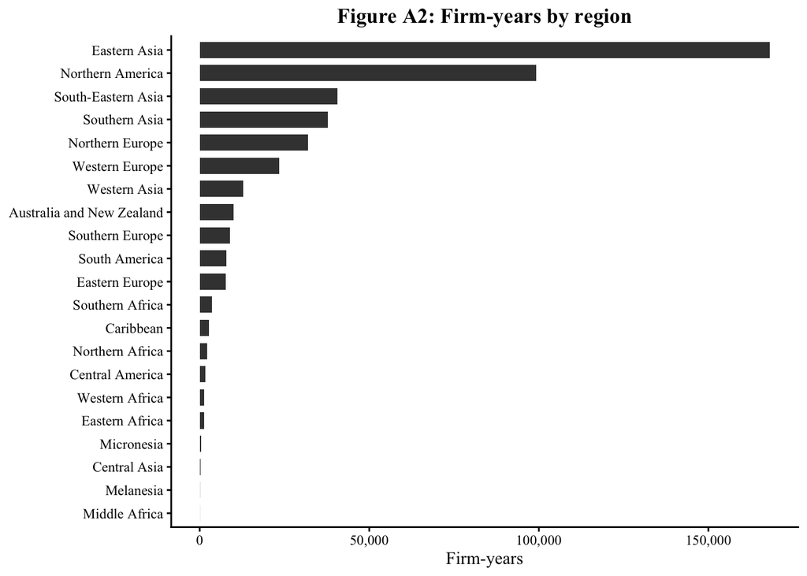

```r
fwrite(by_region, file.path(out, "table_appx_A2_region.csv"))

p_A2 <- ggplot(by_region, aes(x = reorder(region, firm_years), y = firm_years)) +
  geom_col(fill = "grey25", width = 0.7) + coord_flip() +
  scale_y_continuous(labels = scales::comma) +
  labs(x = NULL, y = "Firm-years", title = "Figure A2: Firm-years by region") +
  theme_thesis()
p_A2
```

```r
ggsave(file.path(out, "fig_appx_A2_region.png"), p_A2, width = 7, height = 4.5, dpi = 300)
```

## A3. Distance categories by firm location (United States vs. rest of sample) – underlies R11

```r
af_s[, cat_label := factor(cat_labels_paper[category], levels = cat_labels_paper)]
af_s[d, on = .(gvkey, year = fyear), `:=`(us_firm = i.country == "USA", region = i.region)]

tabA3 <- af_s[, .N, by = .(us_firm, cat_label)]
tabA3[, share := round(100 * N / sum(N), 1), by = us_firm]
tabA3_wide <- dcast(tabA3, cat_label ~ us_firm, value.var = c("N", "share"))
setnames(tabA3_wide, c("cat_label", "N_FALSE", "N_TRUE", "share_FALSE", "share_TRUE"),
         c("Distance category", "Obs. (non-US)", "Obs. (US)", "Share % (non-US)", "Share % (US)"))
knitr::kable(tabA3_wide, format.args = list(big.mark = ","),
             caption = "Table A3: Alliance-firm observations by distance category, United States vs. rest of sample (underlies R11)")
```

Table A3: Alliance-firm observations by distance category, United States vs. rest of sample (underlies R11)

| Distance category | Obs. (non-US) | Obs. (US) | Share % (non-US) | Share % (US) |
| --- | --- | --- | --- | --- |
| D0 (same four-digit SIC) | 2,889 | 3,817 | 12.5 | 13.4 |
| D1 (same three-digit SIC) | 2,702 | 3,973 | 11.7 | 14.0 |
| D2 (same major group) | 2,067 | 2,129 | 8.9 | 7.5 |
| D3 (same SIC division) | 3,797 | 5,024 | 16.4 | 17.7 |
| D4 (different SIC division) | 11,678 | 13,487 | 50.5 | 47.4 |

```r
fwrite(tabA3_wide, file.path(out, "table_appx_A3_us_split.csv"))

# how many firm-years / firms does each side of the R11 split actually have?
d[, .(firm_years = .N, firms = uniqueN(gvkey)), by = .(us_firm = country == "USA")]
```

```
   us_firm firm_years firms
    <lgcl>      <int> <int>
1:    TRUE      88524  9078
2:   FALSE     373358 34333
```

## A4. Distance categories by firm size (below- / above-median) – underlies R12

```r
med_size <- median(d$ln_at_usd, na.rm = TRUE)
af_s[d, on = .(gvkey, year = fyear), below_median := i.ln_at_usd <= med_size]

tabA4 <- af_s[, .N, by = .(below_median, cat_label)]
tabA4[, share := round(100 * N / sum(N), 1), by = below_median]
tabA4_wide <- dcast(tabA4, cat_label ~ below_median, value.var = c("N", "share"))
setnames(tabA4_wide, c("cat_label", "N_FALSE", "N_TRUE", "share_FALSE", "share_TRUE"),
         c("Distance category", "Obs. (above median)", "Obs. (below median)",
           "Share % (above median)", "Share % (below median)"))
knitr::kable(tabA4_wide, format.args = list(big.mark = ","),
             caption = "Table A4: Alliance-firm observations by distance category, below- vs. above-median firm size (underlies R12)")
```

Table A4: Alliance-firm observations by distance category, below- vs. above-median firm size (underlies R12)

| Distance category | Obs. (above median) | Obs. (below median) | Share % (above median) | Share % (below median) |
| --- | --- | --- | --- | --- |
| D0 (same four-digit SIC) | 5,577 | 1,129 | 12.8 | 14.3 |
| D1 (same three-digit SIC) | 5,427 | 1,248 | 12.4 | 15.8 |
| D2 (same major group) | 3,633 | 563 | 8.3 | 7.1 |
| D3 (same SIC division) | 7,436 | 1,385 | 17.0 | 17.5 |
| D4 (different SIC division) | 21,592 | 3,573 | 49.4 | 45.2 |

```r
fwrite(tabA4_wide, file.path(out, "table_appx_A4_size_split.csv"))

d[, .(firm_years = .N, firms = uniqueN(gvkey), median_size_usd_m = round(exp(med_size), 0)),
  by = .(below_median = ln_at_usd <= med_size)]
```

```
   below_median firm_years firms median_size_usd_m
         <lgcl>      <int> <int>             <num>
1:        FALSE     230941 23045               223
2:         TRUE     230941 31287               223
```

## A5. Summary statistics by region and by size group

```r
sum_vars <- c(growth_f3_w = "Revenue growth, g (t to t+3)", ln_at_usd = "Size (ln total assets, USD)",
              roa_w = "ROA", leverage_w = "Leverage", n_alliances_3y = "All alliances")

summarise_by <- function(byvar) {
  rbindlist(lapply(names(sum_vars), function(v) {
    d[, .(variable = sum_vars[[v]], mean = round(mean(get(v)), 3),
          median = round(median(get(v)), 3), sd = round(sd(get(v)), 3), N = .N),
      by = byvar]
  }))
}

tabA5a <- summarise_by("region")
knitr::kable(tabA5a, caption = "Table A5a: Summary statistics by region")
```

Table A5a: Summary statistics by region

| region | variable | mean | median | sd | N |
| --- | --- | --- | --- | --- | --- |
| Northern America | Revenue growth, g (t to t+3) | 0.073 | 0.059 | 0.190 | 99282 |
| Western Europe | Revenue growth, g (t to t+3) | 0.045 | 0.040 | 0.152 | 23470 |
| Western Asia | Revenue growth, g (t to t+3) | 0.094 | 0.067 | 0.223 | 12823 |
| Caribbean | Revenue growth, g (t to t+3) | 0.052 | 0.051 | 0.250 | 2787 |
| South-Eastern Asia | Revenue growth, g (t to t+3) | 0.045 | 0.043 | 0.193 | 40573 |
| Northern Europe | Revenue growth, g (t to t+3) | 0.065 | 0.056 | 0.176 | 31994 |
| Eastern Asia | Revenue growth, g (t to t+3) | 0.053 | 0.037 | 0.178 | 168084 |
| Australia and New Zealand | Revenue growth, g (t to t+3) | 0.063 | 0.056 | 0.215 | 9949 |
| Central America | Revenue growth, g (t to t+3) | 0.081 | 0.084 | 0.156 | 1657 |
| Southern Africa | Revenue growth, g (t to t+3) | 0.092 | 0.084 | 0.164 | 3659 |
| Eastern Africa | Revenue growth, g (t to t+3) | 0.105 | 0.069 | 0.238 | 1261 |
| Southern Asia | Revenue growth, g (t to t+3) | 0.081 | 0.087 | 0.205 | 37769 |
| Southern Europe | Revenue growth, g (t to t+3) | 0.025 | 0.027 | 0.165 | 8921 |
| Western Africa | Revenue growth, g (t to t+3) | 0.109 | 0.091 | 0.188 | 1291 |
| Micronesia | Revenue growth, g (t to t+3) | 0.094 | 0.061 | 0.237 | 436 |
| South America | Revenue growth, g (t to t+3) | 0.108 | 0.092 | 0.200 | 7920 |
| Eastern Europe | Revenue growth, g (t to t+3) | 0.056 | 0.057 | 0.191 | 7597 |
| Melanesia | Revenue growth, g (t to t+3) | 0.161 | 0.116 | 0.182 | 32 |
| Middle Africa | Revenue growth, g (t to t+3) | -0.066 | -0.049 | 0.147 | 18 |
| Central Asia | Revenue growth, g (t to t+3) | 0.112 | 0.090 | 0.165 | 195 |
| Northern Africa | Revenue growth, g (t to t+3) | 0.093 | 0.076 | 0.182 | 2164 |
| Northern America | Size (ln total assets, USD) | 5.887 | 5.792 | 2.069 | 99282 |
| Western Europe | Size (ln total assets, USD) | 6.090 | 5.784 | 2.173 | 23470 |
| Western Asia | Size (ln total assets, USD) | 5.302 | 5.142 | 1.628 | 12823 |
| Caribbean | Size (ln total assets, USD) | 5.537 | 5.412 | 1.607 | 2787 |
| South-Eastern Asia | Size (ln total assets, USD) | 4.800 | 4.590 | 1.488 | 40573 |
| Northern Europe | Size (ln total assets, USD) | 5.571 | 5.296 | 2.000 | 31994 |
| Eastern Asia | Size (ln total assets, USD) | 5.817 | 5.660 | 1.555 | 168084 |
| Australia and New Zealand | Size (ln total assets, USD) | 5.108 | 4.918 | 1.845 | 9949 |
| Central America | Size (ln total assets, USD) | 7.041 | 7.056 | 1.523 | 1657 |

[output cut: 75 more lines]

```r
fwrite(tabA5a, file.path(out, "table_appx_A5a_by_region.csv"))

d[, size_group := fifelse(ln_at_usd <= med_size, "Below median", "Above median")]
tabA5b <- summarise_by("size_group")
knitr::kable(tabA5b, caption = "Table A5b: Summary statistics by size group")
```

Table A5b: Summary statistics by size group

| size_group | variable | mean | median | sd | N |
| --- | --- | --- | --- | --- | --- |
| Above median | Revenue growth, g (t to t+3) | 0.062 | 0.049 | 0.166 | 230941 |
| Below median | Revenue growth, g (t to t+3) | 0.062 | 0.052 | 0.206 | 230941 |
| Above median | Size (ln total assets, USD) | 7.025 | 6.698 | 1.312 | 230941 |
| Below median | Size (ln total assets, USD) | 4.125 | 4.262 | 0.889 | 230941 |
| Above median | ROA | 0.033 | 0.035 | 0.083 | 230941 |
| Below median | ROA | 0.012 | 0.033 | 0.135 | 230941 |
| Above median | Leverage | 0.534 | 0.535 | 0.220 | 230941 |
| Below median | Leverage | 0.475 | 0.455 | 0.245 | 230941 |
| Above median | All alliances | 0.532 | 0.000 | 3.426 | 230941 |
| Below median | All alliances | 0.091 | 0.000 | 0.571 | 230941 |

```r
fwrite(tabA5b, file.path(out, "table_appx_A5b_by_size.csv"))
```

## A6. Panel structure: years observed per firm

```r
yrs_per_firm <- d[, .N, by = gvkey]
tabA6 <- data.table(statistic = c("Mean", "Median", "Min", "Max", "Firms with 1 year only", "Firms observed every year (32)"),
                    value = c(round(mean(yrs_per_firm$N), 2), median(yrs_per_firm$N), min(yrs_per_firm$N),
                              max(yrs_per_firm$N), sum(yrs_per_firm$N == 1), sum(yrs_per_firm$N == uniqueN(d$fyear))))
knitr::kable(tabA6, caption = "Table A6: Panel structure -- years observed per firm")
```

Table A6: Panel structure – years observed per firm

| statistic | value |
| --- | --- |
| Mean | 10.64 |
| Median | 9.00 |
| Min | 1.00 |
| Max | 32.00 |
| Firms with 1 year only | 4061.00 |
| Firms observed every year (32) | 571.00 |

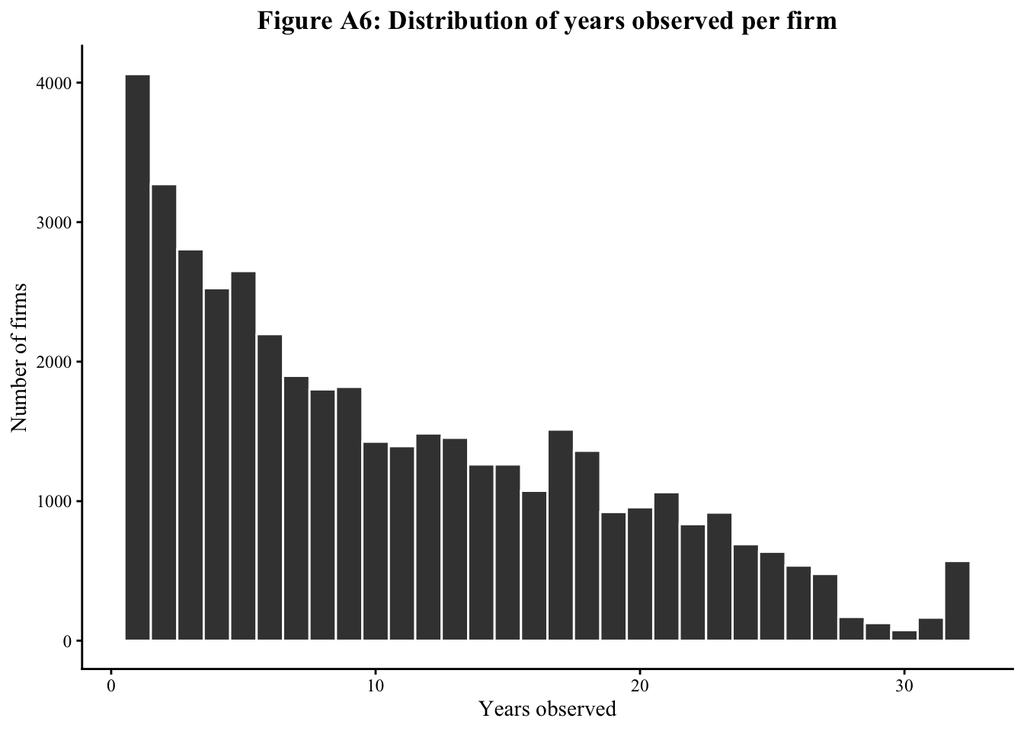

```r
fwrite(tabA6, file.path(out, "table_appx_A6_panel_structure.csv"))

p_A6 <- ggplot(yrs_per_firm, aes(x = N)) +
  geom_histogram(binwidth = 1, fill = "grey25", colour = "white") +
  labs(x = "Years observed", y = "Number of firms", title = "Figure A6: Distribution of years observed per firm") +
  theme_thesis()
p_A6
```

```r
ggsave(file.path(out, "fig_appx_A6_panel_structure.png"), p_A6, width = 6, height = 4, dpi = 300)
```

## A7. Firm-years by year, and number of distinct firms/countries per year

Complements Figure 5 (which counts alliances, but not firm-years).

```r
tabA7 <- d[, .(firm_years = .N, firms = uniqueN(gvkey), countries = uniqueN(country)), by = fyear][order(fyear)]
knitr::kable(tabA7, format.args = list(big.mark = ","), caption = "Table A7: Firm-years, firms and countries by year")
```

Table A7: Firm-years, firms and countries by year

| fyear | firm_years | firms | countries |
| --- | --- | --- | --- |
| 1,990 | 3,755 | 3,755 | 28 |
| 1,991 | 4,435 | 4,435 | 36 |
| 1,992 | 4,478 | 4,478 | 35 |
| 1,993 | 4,760 | 4,760 | 41 |
| 1,994 | 5,016 | 5,016 | 42 |
| 1,995 | 5,882 | 5,882 | 43 |
| 1,996 | 6,497 | 6,497 | 50 |
| 1,997 | 7,455 | 7,455 | 56 |
| 1,998 | 8,398 | 8,398 | 69 |
| 1,999 | 9,414 | 9,414 | 80 |
| 2,000 | 10,033 | 10,033 | 87 |
| 2,001 | 11,778 | 11,778 | 92 |
| 2,002 | 12,212 | 12,212 | 94 |
| 2,003 | 12,913 | 12,913 | 100 |
| 2,004 | 14,174 | 14,174 | 100 |
| 2,005 | 15,552 | 15,552 | 105 |
| 2,006 | 16,404 | 16,404 | 108 |
| 2,007 | 17,221 | 17,221 | 108 |
| 2,008 | 17,874 | 17,874 | 112 |
| 2,009 | 18,571 | 18,571 | 112 |
| 2,010 | 19,059 | 19,059 | 112 |
| 2,011 | 19,630 | 19,630 | 115 |
| 2,012 | 19,810 | 19,810 | 115 |
| 2,013 | 20,449 | 20,449 | 114 |
| 2,014 | 20,760 | 20,760 | 115 |
| 2,015 | 20,956 | 20,956 | 115 |
| 2,016 | 21,091 | 21,091 | 116 |
| 2,017 | 21,722 | 21,722 | 117 |
| 2,018 | 22,194 | 22,194 | 116 |
| 2,019 | 22,666 | 22,666 | 115 |
| 2,020 | 23,143 | 23,143 | 116 |
| 2,021 | 23,580 | 23,580 | 116 |

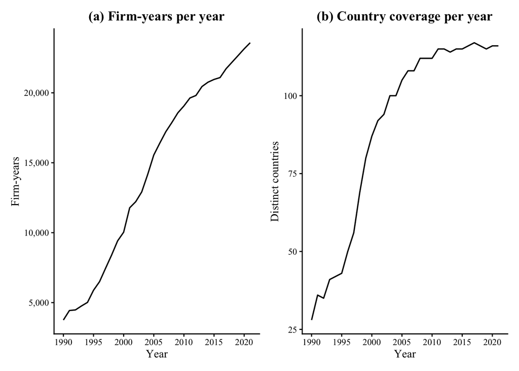

```r
fwrite(tabA7, file.path(out, "table_appx_A7_by_year.csv"))

# No SDC-gap shading here: these are Compustat firm-years, which is not the
# series that has a 2009-2015 coverage gap (that gap is in the SDC alliance
# data -- see the main text's discussion of SDC coverage). Shading it here
# would just invite the reader to look for a dip that isn't there.
p_A7a <- ggplot(tabA7, aes(x = fyear, y = firm_years)) +
  geom_line(colour = "black", linewidth = 0.6) +
  scale_x_continuous(breaks = seq(1990, 2020, 5)) + scale_y_continuous(labels = scales::comma) +
  labs(x = "Year", y = "Firm-years", title = "(a) Firm-years per year") + theme_thesis()
p_A7b <- ggplot(tabA7, aes(x = fyear, y = countries)) +
  geom_line(colour = "black", linewidth = 0.6) +
  scale_x_continuous(breaks = seq(1990, 2020, 5)) +
  labs(x = "Year", y = "Distinct countries", title = "(b) Country coverage per year") + theme_thesis()
fig_A7 <- p_A7a + p_A7b
fig_A7
```

```r
ggsave(file.path(out, "fig_appx_A7_by_year.png"), fig_A7, width = 9, height = 4, dpi = 300)
```

## A8. What the revenue floor is cutting – underlies R10

The main sample has a USD 10m revenue floor. R10 in Table 11 asks how much that choice matters,in two ways: (1) by raising the floor to USD 20m (does the result survive on an even cleaner sample?) and (2) by removing it entirely (does the result survive when small firms come back in?). This table and figure show, in firm-years, exactly what each of those two moves would add or remove.

```r
tabA8 <- data.table(
  sample = c("Main (floor = USD 10m)", "Stricter (floor = USD 20m)", "No floor"),
  firm_years = c(nrow(d), nrow(d[revt_usd_lag >= 20]), nrow(d_nofloor)),
  vs_main = c(0, nrow(d[revt_usd_lag >= 20]) - nrow(d), nrow(d_nofloor) - nrow(d)))
knitr::kable(tabA8, format.args = list(big.mark = ","),
             caption = "Table A8: Firm-years under each revenue-floor variant tested in R10")
```

Table A8: Firm-years under each revenue-floor variant tested in R10

| sample | firm_years | vs_main |
| --- | --- | --- |
| Main (floor = USD 10m) | 461,882 | 0 |
| Stricter (floor = USD 20m) | 423,158 | -38,724 |
| No floor | 539,485 | 77,603 |

```r
fwrite(tabA8, file.path(out, "table_appx_A8_revenue_floor.csv"))

# Distribution of revt_usd_lag among firm-years that are sample-eligible on
# every OTHER criterion (d_nofloor) -- i.e. exactly the population the floor
# decision is drawn from, not the raw, unfiltered panel (which also contains
# financial firms, excluded industries, etc. that the floor choice never
# touches either way).
bins <- c(0, 5, 10, 15, 20, 25, 30, 50, 100, Inf)
tabA8b <- d_nofloor[, .N, by = .(bin = cut(revt_usd_lag, bins, right = FALSE))][order(bin)]
knitr::kable(tabA8b, format.args = list(big.mark = ","),
             caption = "Table A8b: Firm-years by lagged revenue bin, USD million (sample-eligible except for the floor)")
```

Table A8b: Firm-years by lagged revenue bin, USD million (sample-eligible except for the floor)

| bin | N |
| --- | --- |
| [0,5) | 51,639 |
| [5,10) | 25,899 |
| [10,15) | 20,737 |
| [15,20) | 17,987 |
| [20,25) | 15,837 |
| [25,30) | 14,002 |
| [30,50) | 43,831 |
| [50,100) | 66,578 |
| [100,Inf) | 282,910 |
| NA | 65 |

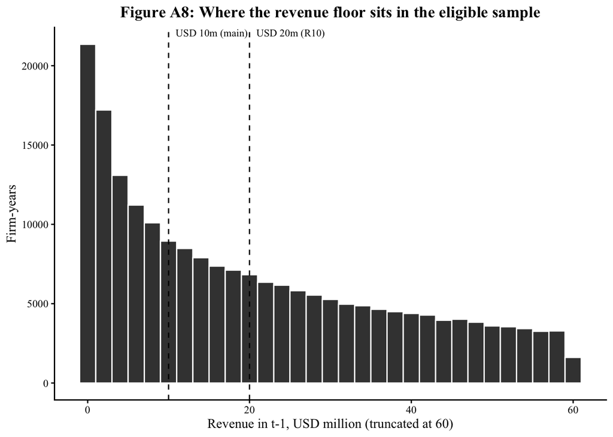

```r
fwrite(tabA8b, file.path(out, "table_appx_A8b_revenue_bins.csv"))

p_A8 <- ggplot(d_nofloor[revt_usd_lag >= 0 & revt_usd_lag < 60], aes(x = revt_usd_lag)) +
  geom_histogram(binwidth = 2, fill = "grey25", colour = "white") +
  geom_vline(xintercept = c(10, 20), linetype = "dashed") +
  annotate("text", x = c(10, 20), y = Inf, label = c("USD 10m (main)", "USD 20m (R10)"), vjust = 1.3, hjust = -0.1,
           family = "Times New Roman", size = 3) +
  labs(x = "Revenue in t-1, USD million (truncated at 60)", y = "Firm-years",
       title = "Figure A8: Where the revenue floor sits in the eligible sample") +
  theme_thesis()
p_A8
```

```r
ggsave(file.path(out, "fig_appx_A8_revenue_floor.png"), p_A8, width = 6, height = 4, dpi = 300)
```

## A9. Industry (2-digit SIC) distribution of the sample

```r
# Standard two-digit SIC major-group titles (the official US SIC manual division
# of 2-digit codes; this is a fixed public classification, not something inferred
# from your data, so it can't drift the way a hand-guessed label could)
sic2_titles <- c(
  "01" = "Agricultural production - crops", "02" = "Agricultural production - livestock",
  "07" = "Agricultural services", "08" = "Forestry", "09" = "Fishing, hunting, and trapping",
  "10" = "Metal mining", "12" = "Coal mining", "13" = "Oil and gas extraction",
  "14" = "Nonmetallic minerals mining", "15" = "Building construction - general contractors",
  "16" = "Heavy construction, other than building", "17" = "Construction - special trade contractors",
  "20" = "Food and kindred products", "21" = "Tobacco products", "22" = "Textile mill products",
  "23" = "Apparel and other finished products", "24" = "Lumber and wood products",
  "25" = "Furniture and fixtures", "26" = "Paper and allied products",
  "27" = "Printing, publishing, and allied industries", "28" = "Chemicals and allied products",
  "29" = "Petroleum refining and related industries", "30" = "Rubber and misc. plastics products",
  "31" = "Leather and leather products", "32" = "Stone, clay, glass, and concrete products",
  "33" = "Primary metal industries", "34" = "Fabricated metal products",
  "35" = "Industrial and commercial machinery, computer equipment",
  "36" = "Electronic and other electrical equipment", "37" = "Transportation equipment",
  "38" = "Measuring, analyzing, and controlling instruments", "39" = "Misc. manufacturing industries",
  "40" = "Railroad transportation", "41" = "Local and suburban transit",
  "42" = "Motor freight transportation", "44" = "Water transportation", "45" = "Transportation by air",
  "46" = "Pipelines, except natural gas", "47" = "Transportation services", "48" = "Communications",
  "49" = "Electric, gas, and sanitary services", "50" = "Wholesale trade - durable goods",
  "51" = "Wholesale trade - nondurable goods", "52" = "Building materials, hardware, garden supply",
  "53" = "General merchandise stores", "54" = "Food stores",
  "55" = "Automotive dealers and gas stations", "56" = "Apparel and accessory stores",
  "57" = "Home furniture and furnishings stores", "58" = "Eating and drinking places",
  "59" = "Miscellaneous retail", "60" = "Depository institutions", "61" = "Nondepository credit institutions",
  "62" = "Security and commodity brokers", "63" = "Insurance carriers",
  "64" = "Insurance agents, brokers, and service", "65" = "Real estate",
  "67" = "Holding and other investment offices", "70" = "Hotels and other lodging places",
  "72" = "Personal services", "73" = "Business services", "75" = "Automotive repair and services",
  "76" = "Miscellaneous repair services", "78" = "Motion pictures", "79" = "Amusement and recreation services",
  "80" = "Health services", "81" = "Legal services", "82" = "Educational services",
  "83" = "Social services", "84" = "Museums, botanical and zoological gardens",
  "86" = "Membership organizations", "87" = "Engineering, accounting, research, management services",
  "88" = "Private households", "89" = "Services, not elsewhere classified",
  "91" = "Executive, legislative, and general government", "92" = "Justice, public order, and safety",
  "93" = "Public finance, taxation, and monetary policy", "94" = "Administration of human resources",
  "95" = "Administration of environmental quality", "96" = "Administration of economic programs",
  "97" = "National security and international affairs", "99" = "Nonclassifiable establishments")

tabA9 <- d[, .(firm_years = .N), by = sic2][order(-firm_years)][1:20]
tabA9[, `:=`(industry = sic2_titles[as.character(sic2)], share_pct = round(100 * firm_years / nrow(d), 1))]
setcolorder(tabA9, c("sic2", "industry", "firm_years", "share_pct"))
unlabelled <- tabA9[is.na(industry), as.character(sic2)]
if (length(unlabelled) > 0) cat("SIC2 codes with no title in the dictionary above (check these):",
                                 paste(unlabelled, collapse = ", "), "\n")
knitr::kable(tabA9, format.args = list(big.mark = ","),
             caption = "Table A9: Top 20 two-digit SIC industries by firm-years")
```

Table A9: Top 20 two-digit SIC industries by firm-years

| sic2 | industry | firm_years | share_pct |
| --- | --- | --- | --- |
| 36 | Electronic and other electrical equipment | 43,427 | 9.4 |
| 73 | Business services | 40,221 | 8.7 |
| 28 | Chemicals and allied products | 40,212 | 8.7 |
| 35 | Industrial and commercial machinery, computer equipment | 32,091 | 6.9 |
| 20 | Food and kindred products | 26,336 | 5.7 |
| 33 | Primary metal industries | 17,699 | 3.8 |
| 50 | Wholesale trade - durable goods | 16,536 | 3.6 |
| 37 | Transportation equipment | 16,264 | 3.5 |
| 38 | Measuring, analyzing, and controlling instruments | 15,203 | 3.3 |
| 32 | Stone, clay, glass, and concrete products | 11,324 | 2.5 |
| 48 | Communications | 11,135 | 2.4 |
| 22 | Textile mill products | 10,583 | 2.3 |
| 34 | Fabricated metal products | 9,548 | 2.1 |
| 30 | Rubber and misc. plastics products | 9,515 | 2.1 |
| 51 | Wholesale trade - nondurable goods | 9,422 | 2.0 |
| 87 | Engineering, accounting, research, management services | 8,313 | 1.8 |
| 13 | Oil and gas extraction | 7,920 | 1.7 |
| 26 | Paper and allied products | 7,644 | 1.7 |
| 16 | Heavy construction, other than building | 7,258 | 1.6 |
| 59 | Miscellaneous retail | 6,923 | 1.5 |

```r
fwrite(tabA9, file.path(out, "table_appx_A9_sic2.csv"))
```

## A10. Industry distance between alliance partners, by decade

```r
af_s[, cat_label := factor(cat_labels[category], levels = cat_labels)]
af_s[, period := paste0((year %/% 10) * 10, "s")]

tabA10 <- af_s[, .N, by = .(period, cat_label)]
tabA10[, share := round(N / sum(N), 3), by = period]
tabA10_wide <- dcast(tabA10, cat_label ~ period, value.var = "share")
overall10   <- af_s[, .N, by = cat_label][, .(cat_label, all_years = round(N / sum(N), 3))]
tabA10_wide <- overall10[tabA10_wide, on = "cat_label"]
knitr::kable(tabA10_wide, caption = "Table A10: Industry distance between alliance partners, by decade")
```

Table A10: Industry distance between alliance partners, by decade

| cat_label | all_years | 1990s | 2000s | 2010s | 2020s |
| --- | --- | --- | --- | --- | --- |
| D0 same 4-digit SIC | 0.130 | 0.136 | 0.150 | 0.123 | 0.093 |
| D1 same 3-digit SIC | 0.129 | 0.110 | 0.146 | 0.129 | 0.152 |
| D2 same major group | 0.081 | 0.085 | 0.088 | 0.079 | 0.064 |
| D3 same division | 0.171 | 0.198 | 0.159 | 0.156 | 0.150 |
| D4 different division | 0.488 | 0.471 | 0.457 | 0.514 | 0.541 |

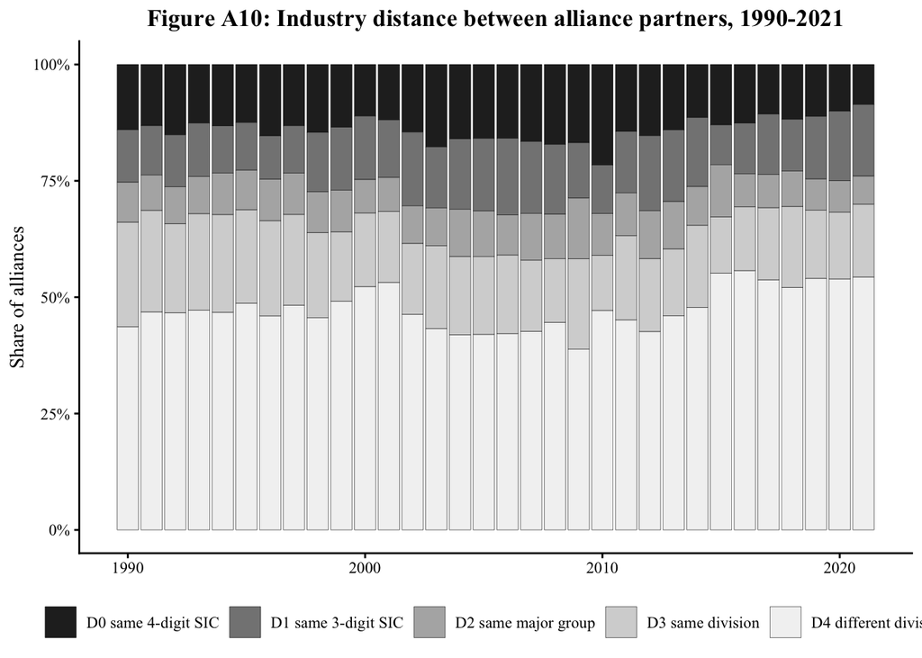

```r
fwrite(tabA10_wide, file.path(out, "table_appx_A10_distance_by_decade.csv"))

figA10 <- ggplot(af_s[, .N, by = .(year, cat_label)],
                 aes(x = year, y = N, fill = cat_label)) +
  geom_col(position = "fill", width = 0.9, colour = "black", linewidth = 0.1) +
  scale_y_continuous(labels = scales::percent) +
  scale_fill_grey(start = 0.15, end = 0.95) +
  labs(x = NULL, y = "Share of alliances", fill = NULL,
       title = "Figure A10: Industry distance between alliance partners, 1990-2021") +
  theme_thesis()
figA10
```

```r
ggsave(file.path(out, "fig_appx_A10_distance_by_year.png"), figA10, width = 8, height = 4.5, dpi = 300)
```

# Appendix B: Full Regression Results

This section reports every coefficient for H1, H2 and B1.

```r
m2_full <- est(rhs_h2)                 # H1 (Table 8, col b)
m4_full <- est(rhs_h4)                 # H2 (Table 9)
m1_full <- est(rhs_h1)                 # B1 (Table 10)

etable(m2_full, m4_full, m1_full,
       headers = c("H1", "H2", "B1"),
       dict = c(cat_labels_paper, ln_at_usd = "Size (ln assets, USD)", roa_w = "ROA",
                leverage_w = "Leverage", growth_l1_w = "Past growth"),
       fitstat = ~ n + r2 + wr2,
       tex = FALSE, file = file.path(out, "table_appx_B1_full_models.txt"), replace = TRUE)
tab_appx_b1 <- etable(m2_full, m4_full, m1_full,
       headers = c("H1", "H2", "B1"),
       dict = c(cat_labels_paper, ln_at_usd = "Size (ln assets, USD)", roa_w = "ROA",
                leverage_w = "Leverage", growth_l1_w = "Past growth"),
       fitstat = ~ n + r2 + wr2, tex = FALSE)
knitr::kable(tab_appx_b1)
```

|  | m2_full | m4_full | m1_full |
| --- | --- | --- | --- |
|  | H1 | H2 | B1 |
| Dependent Var.: | growth_f3_w | growth_f3_w | growth_f3_w |
| log1p(d0_same4_3y) | -0.0064* (0.0033) |  |  |
| log1p(d1_same3_3y) | -0.0040 (0.0034) |  |  |
| log1p(d2_same2_3y) | -0.0012 (0.0030) |  |  |
| log1p(d3_same_division_3y) | 0.0014 (0.0024) |  |  |
| log1p(d4_diff_division_3y) | -0.0042* (0.0018) |  |  |
| Size (ln assets, USD) | -0.0886*** (0.0012) | -0.0886*** (0.0012) | -0.0886*** (0.0012) |
| ROA | -0.0072 (0.0051) | -0.0072 (0.0051) | -0.0072 (0.0051) |
| Leverage | -0.1024*** (0.0039) | -0.1024*** (0.0039) | -0.1024*** (0.0039) |
| Past growth | -0.0089*** (0.0012) | -0.0089*** (0.0012) | -0.0089*** (0.0012) |
| log1p(d0_same4_eq_3y) |  | -0.0027 (0.0050) |  |
| log1p(d0_same4_ne_3y) |  | -0.0070. (0.0037) |  |
| log1p(d1_same3_eq_3y) |  | -0.0064 (0.0059) |  |
| log1p(d1_same3_ne_3y) |  | -0.0023 (0.0038) |  |
| log1p(d2_same2_eq_3y) |  | -0.0014 (0.0043) |  |
| log1p(d2_same2_ne_3y) |  | -0.0005 (0.0038) |  |
| log1p(d3_same_division_eq_3y) |  | 0.0029 (0.0038) |  |
| log1p(d3_same_division_ne_3y) |  | 0.0014 (0.0028) |  |
| log1p(d4_diff_division_eq_3y) |  | -0.0014 (0.0029) |  |
| log1p(d4_diff_division_ne_3y) |  | -0.0051* (0.0021) |  |
| log1p(n_rel_3y) |  |  | -0.0033. (0.0017) |
| log1p(n_unrel_3y) |  |  | -0.0042* (0.0019) |
| Fixed-Effects: | ——————- | ——————- | ——————- |
| gvkey | Yes | Yes | Yes |
| sic2-fyear | Yes | Yes | Yes |
| country-fyear | Yes | Yes | Yes |
| _____________________________ | ___________________ | ___________________ | ___________________ |
| S.E.: Clustered | by: gvkey | by: gvkey | by: gvkey |
| Observations | 457,325 | 457,325 | 457,325 |
| R2 | 0.44288 | 0.44288 | 0.44287 |
| Within R2 | 0.08182 | 0.08183 | 0.08181 |

## B2. Robustness checks: full coefficients where they add something, p-values for all twelve

```r
d[, sic2 := as.factor(sic2)]
d[, t_c := as.numeric(fyear) - 2005]   # centred year, needed for gvkey[t_c] firm-specific linear trends (R5; same convention as file 07)
med_size <- median(d$ln_at_usd, na.rm = TRUE)
# d_nofloor was built in the setup chunk above (also used by Figure A8)

m_R1  <- est(rhs_h2, fe = "gvkey + sic2^fyear")
m_R2  <- est(rhs_h2, fe = "gvkey + country^fyear")
m_R3  <- est(rhs_h2, fe = "sic2^fyear + country^fyear")
m_R4  <- est(rhs_h2, ctrl = NULL)
m_R5  <- est(rhs_h2, fe = "gvkey[t_c] + sic2^fyear + country^fyear")
m_R6  <- est(rhs_h2, y = "growth_f1_w")
# R7: four alliance-window variants (year t only -- the bare, un-windowed counts -- plus 2y/4y/5y; see 04_analysis_sample.qmd)
m_R7_t  <- est(rhs_dist(""))
m_R7_w2 <- est(rhs_dist("_w2"))
m_R7_w4 <- est(rhs_dist("_w4"))
m_R7_w5 <- est(rhs_dist("_w5"))

# R8: placebo test, growth t-6 to t-3 (before the alliance window even opens).
# Ported from 07_robustness_checks.qmd's Panel B construction.
rv <- fp[, .(gvkey, fyear, revt, curcd)]
add_rev <- function(dt, k, name) {
  x <- rv[, .(gvkey, fyear = fyear - as.integer(k), r = revt, cur = curcd)]
  cols <- c(name, paste0(name, "_cur"))
  setnames(x, c("r", "cur"), cols)
  dt[x, on = .(gvkey, fyear), (cols) := mget(paste0("i.", cols))]
  dt
}
ann <- function(r1, c1, r0, c0, n) fifelse(r1 > 0 & r0 > 0 & c1 == c0, (r1 / r0)^(1 / n) - 1, NA_real_)
d <- add_rev(d, -6, "r_m6")
d <- add_rev(d, -3, "r_m3")
d[, g_pre := wins(ann(r_m3, r_m3_cur, r_m6, r_m6_cur, 3))]   # growth t-6 to t-3
ctrl_placebo <- "ln_at_usd + roa_w + leverage_w"   # past growth is dropped: it lies after the outcome period
m_R8a <- est(rhs_h2, y = "g_pre", ctrl = ctrl_placebo)
m_R8b <- est(rhs_h2, y = "g_pre", ctrl = NULL)

m_R9  <- est(rhs_h2, data = d[!(fyear %between% c(2009, 2015))])
m_R10a <- est(rhs_h2, data = d[revt_usd_lag >= 20])
m_R10b <- est(rhs_h2, data = d_nofloor)
m_R11a <- est(rhs_h2, data = d[country == "USA"])
m_R11b <- est(rhs_h2, data = d[country != "USA"])
m_R12a <- est(rhs_h2, data = d[ln_at_usd <= med_size])
m_R12b <- est(rhs_h2, data = d[ln_at_usd >  med_size])

dict_appx <- c(cat_labels_paper, ln_at_usd = "Size (ln assets, USD)", roa_w = "ROA",
               leverage_w = "Leverage", growth_l1_w = "Past growth")

# Full coefficients only for R3 and R4: these are the two where the omnibus/
# joint p-values in Table 11 actually move (R3 and R4 both go to p < 0.01),
# so seeing the coefficient pattern tells you something -- most likely that
# dropping the firm FE (R3) or the controls (R4) lets between-firm variation
# leak back into the estimate. R1, R2, R5 and R6 all land close to the main
# result (Table 11 p-values 0.26-0.60), so a full coefficient table for them
# would just re-confirm "nothing changed" -- the p-value cross-check further
# below covers that without spending appendix space on it.
etable(m2_full, m_R3, m_R4,
       headers = c("Main", "R3 (no firm FE)", "R4 (no controls)"),
       dict = dict_appx, fitstat = ~ n + r2 + wr2,
       file = file.path(out, "table_appx_B2a_robustness_R3_R4.txt"), replace = TRUE)
tab_appx_b2a <- etable(m2_full, m_R3, m_R4,
       headers = c("Main", "R3 (no firm FE)", "R4 (no controls)"), dict = dict_appx, fitstat = ~ n + r2 + wr2, tex = FALSE)
knitr::kable(tab_appx_b2a)
```

|  | m2_full | m_R3 | m_R4 |
| --- | --- | --- | --- |
|  | Main | R3 (no firm FE) | R4 (no controls) |
| Dependent Var.: | growth_f3_w | growth_f3_w | growth_f3_w |
| log1p(d0_same4_3y) | -0.0064* (0.0033) | 0.0069* (0.0028) | -0.0110** (0.0034) |
| log1p(d1_same3_3y) | -0.0040 (0.0034) | 0.0112*** (0.0033) | -0.0138*** (0.0037) |
| log1p(d2_same2_3y) | -0.0012 (0.0030) | -0.0060* (0.0030) | -0.0062* (0.0031) |
| log1p(d3_same_division_3y) | 0.0014 (0.0024) | 0.0003 (0.0024) | -0.0041. (0.0025) |
| log1p(d4_diff_division_3y) | -0.0042* (0.0018) | -0.0039* (0.0017) | -0.0170*** (0.0019) |
| Size (ln assets, USD) | -0.0886*** (0.0012) | 0.0004 (0.0003) |  |
| ROA | -0.0072 (0.0051) | 0.1463*** (0.0048) |  |
| Leverage | -0.1024*** (0.0039) | -0.0464*** (0.0022) |  |
| Past growth | -0.0089*** (0.0012) | 0.0228*** (0.0012) |  |
| Fixed-Effects: | ——————- | ——————- | ——————- |
| gvkey | Yes | No | Yes |
| sic2-fyear | Yes | Yes | Yes |
| country-fyear | Yes | Yes | Yes |
| __________________________ | ___________________ | ___________________ | ___________________ |
| S.E.: Clustered | by: gvkey | by: gvkey | by: gvkey |
| Observations | 457,325 | 461,393 | 457,325 |
| R2 | 0.44288 | 0.14745 | 0.39374 |
| Within R2 | 0.08182 | 0.01784 | 0.00083 |

```r
etable(m2_full, m_R7_t, m_R7_w2, m_R7_w4, m_R7_w5,
       headers = c("Main (3y)", "R7 (year t only)", "R7 (2y window)", "R7 (4y window)", "R7 (5y window)"),
       dict = dict_appx, fitstat = ~ n + r2 + wr2,
       file = file.path(out, "table_appx_B2b_robustness_R7.txt"), replace = TRUE)
tab_appx_b2b <- etable(m2_full, m_R7_t, m_R7_w2, m_R7_w4, m_R7_w5,
       headers = c("Main (3y)", "R7 (year t only)", "R7 (2y window)", "R7 (4y window)", "R7 (5y window)"),
       dict = dict_appx, fitstat = ~ n + r2 + wr2, tex = FALSE)
knitr::kable(tab_appx_b2b)
```

|  | m2_full | m_R7_t | m_R7_w2 | m_R7_w4 | m_R7_w5 |
| --- | --- | --- | --- | --- | --- |
|  | Main (3y) | R7 (year t only) | R7 (2y window) | R7 (4y window) | R7 (5y window) |
| Dependent Var.: | growth_f3_w | growth_f3_w | growth_f3_w | growth_f3_w | growth_f3_w |
| log1p(d0_same4_3y) | -0.0064* (0.0033) |  |  |  |  |
| log1p(d1_same3_3y) | -0.0040 (0.0034) |  |  |  |  |
| log1p(d2_same2_3y) | -0.0012 (0.0030) |  |  |  |  |
| log1p(d3_same_division_3y) | 0.0014 (0.0024) |  |  |  |  |
| log1p(d4_diff_division_3y) | -0.0042* (0.0018) |  |  |  |  |
| Size (ln assets, USD) | -0.0886*** (0.0012) | -0.0887*** (0.0012) | -0.0887*** (0.0012) | -0.0885*** (0.0012) | -0.0884*** (0.0012) |
| ROA | -0.0072 (0.0051) | -0.0070 (0.0051) | -0.0071 (0.0051) | -0.0073 (0.0051) | -0.0074 (0.0051) |
| Leverage | -0.1024*** (0.0039) | -0.1024*** (0.0039) | -0.1024*** (0.0039) | -0.1024*** (0.0039) | -0.1023*** (0.0039) |
| Past growth | -0.0089*** (0.0012) | -0.0088*** (0.0012) | -0.0088*** (0.0012) | -0.0089*** (0.0012) | -0.0090*** (0.0012) |
| log1p(d0_same4) |  | -0.0041 (0.0033) |  |  |  |
| log1p(d1_same3) |  | 0.0015 (0.0035) |  |  |  |
| log1p(d2_same2) |  | -0.0025 (0.0033) |  |  |  |
| log1p(d3_same_division) |  | 0.0010 (0.0028) |  |  |  |
| log1p(d4_diff_division) |  | -0.0008 (0.0020) |  |  |  |
| log1p(d0_same4_w2) |  |  | -0.0060. (0.0033) |  |  |
| log1p(d1_same3_w2) |  |  | -0.0018 (0.0034) |  |  |
| log1p(d2_same2_w2) |  |  | -0.0023 (0.0032) |  |  |
| log1p(d3_same_division_w2) |  |  | 0.0020 (0.0025) |  |  |
| log1p(d4_diff_division_w2) |  |  | -0.0022 (0.0019) |  |  |
| log1p(d0_same4_w4) |  |  |  | -0.0059. (0.0033) |  |
| log1p(d1_same3_w4) |  |  |  | -0.0054 (0.0034) |  |
| log1p(d2_same2_w4) |  |  |  | 0.0002 (0.0030) |  |
| log1p(d3_same_division_w4) |  |  |  | 0.0011 (0.0024) |  |
| log1p(d4_diff_division_w4) |  |  |  | -0.0063*** (0.0019) |  |
| log1p(d0_same4_w5) |  |  |  |  | -0.0052 (0.0032) |
| log1p(d1_same3_w5) |  |  |  |  | -0.0055 (0.0034) |
| log1p(d2_same2_w5) |  |  |  |  | 0.0008 (0.0029) |
| log1p(d3_same_division_w5) |  |  |  |  | 0.0003 (0.0024) |
| log1p(d4_diff_division_w5) |  |  |  |  | -0.0078*** (0.0019) |
| Fixed-Effects: | ——————- | ——————- | ——————- | ——————- | ——————- |
| gvkey | Yes | Yes | Yes | Yes | Yes |
| sic2-fyear | Yes | Yes | Yes | Yes | Yes |
| country-fyear | Yes | Yes | Yes | Yes | Yes |
| __________________________ | ___________________ | ___________________ | ___________________ | ___________________ | ___________________ |
| S.E.: Clustered | by: gvkey | by: gvkey | by: gvkey | by: gvkey | by: gvkey |
| Observations | 457,325 | 457,325 | 457,325 | 457,325 | 457,325 |
| R2 | 0.44288 | 0.44284 | 0.44285 | 0.44291 | 0.44294 |
| Within R2 | 0.08182 | 0.08176 | 0.08178 | 0.08188 | 0.08192 |

```r
etable(m2_full, m_R8a, m_R8b, m_R9, m_R10a, m_R10b, m_R11a, m_R11b, m_R12a, m_R12b,
       headers = c("Main", "R8 (placebo, controls)", "R8 (placebo, no controls)", "R9", "R10 (20m)",
                   "R10 (no floor)", "R11 (US)", "R11 (non-US)", "R12 (below med.)", "R12 (above med.)"),
       dict = dict_appx, fitstat = ~ n + r2 + wr2,
       file = file.path(out, "table_appx_B2c_robustness_R8_R12.txt"), replace = TRUE)
tab_appx_b2c <- etable(m2_full, m_R8a, m_R8b, m_R9, m_R10a, m_R10b, m_R11a, m_R11b, m_R12a, m_R12b,
       headers = c("Main", "R8 (placebo, controls)", "R8 (placebo, no controls)", "R9", "R10 (20m)",
                   "R10 (no floor)", "R11 (US)", "R11 (non-US)", "R12 (below med.)", "R12 (above med.)"),
       dict = dict_appx, fitstat = ~ n + r2 + wr2, tex = FALSE)
knitr::kable(tab_appx_b2c)
```

|  | m2_full | m_R8a | m_R8b | m_R9 | m_R10a | m_R10b | m_R11a | m_R11b | m_R12a | m_R12b |
| --- | --- | --- | --- | --- | --- | --- | --- | --- | --- | --- |
|  | Main | R8 (placebo, controls) | R8 (placebo, no controls) | R9 | R10 (20m) | R10 (no floor) | R11 (US) | R11 (non-US) | R12 (below med.) | R12 (above med.) |
| Dependent Var.: | growth_f3_w | g_pre | g_pre | growth_f3_w | growth_f3_w | growth_f3_w | growth_f3_w | growth_f3_w | growth_f3_w | growth_f3_w |
| log1p(d0_same4_3y) | -0.0064* (0.0033) | 0.0058 (0.0050) | 0.0085. (0.0049) | -0.0081* (0.0036) | -0.0060. (0.0032) | -0.0102* (0.0048) | -0.0091. (0.0052) | -0.0035 (0.0040) | 0.0024 (0.0086) | -0.0049 (0.0034) |
| log1p(d1_same3_3y) | -0.0040 (0.0034) | 0.0085 (0.0063) | 0.0140* (0.0062) | -0.0068. (0.0038) | -0.0034 (0.0033) | -0.0140** (0.0053) | -0.0042 (0.0053) | -0.0040 (0.0042) | 0.0068 (0.0088) | -0.0052 (0.0037) |
| log1p(d2_same2_3y) | -0.0012 (0.0030) | -0.0039 (0.0045) | -0.0005 (0.0045) | -0.0009 (0.0034) | -0.0009 (0.0030) | -0.0003 (0.0043) | -0.0034 (0.0047) | -0.0004 (0.0040) | 0.0055 (0.0113) | -0.0011 (0.0030) |
| log1p(d3_same_division_3y) | 0.0014 (0.0024) | -0.0036 (0.0036) | 3.42e-5 (0.0036) | 0.0008 (0.0026) | 0.0001 (0.0024) | 0.0015 (0.0034) | 0.0038 (0.0037) | 0.0006 (0.0031) | 0.0203** (0.0072) | -0.0006 (0.0025) |
| log1p(d4_diff_division_3y) | -0.0042* (0.0018) | -0.0021 (0.0031) | 0.0065* (0.0031) | -0.0049* (0.0021) | -0.0031. (0.0018) | -0.0011 (0.0026) | -0.0105*** (0.0029) | 0.0008 (0.0024) | -0.0170*** (0.0051) | -0.0014 (0.0019) |
| Size (ln assets, USD) | -0.0886*** (0.0012) | 0.0750*** (0.0018) |  | -0.0806*** (0.0013) | -0.0871*** (0.0012) | -0.1263*** (0.0018) | -0.0832*** (0.0022) | -0.0901*** (0.0014) | -0.0959*** (0.0019) | -0.0926*** (0.0017) |
| ROA | -0.0072 (0.0051) | -0.0457*** (0.0079) |  | -0.0146* (0.0059) | 0.0003 (0.0054) | -0.0503*** (0.0047) | -0.0007 (0.0085) | -0.0090 (0.0064) | -0.0137* (0.0063) | -0.0232** (0.0083) |
| Leverage | -0.1024*** (0.0039) | -0.0174** (0.0058) |  | -0.0945*** (0.0045) | -0.1018*** (0.0040) | -0.0703*** (0.0044) | -0.0929*** (0.0069) | -0.1054*** (0.0046) | -0.1171*** (0.0054) | -0.0911*** (0.0054) |
| Past growth | -0.0089*** (0.0012) |  |  | -0.0159*** (0.0014) | -0.0084*** (0.0012) | -0.0190*** (0.0011) | 0.0051. (0.0026) | -0.0128*** (0.0013) | -0.0169*** (0.0016) | -0.0109*** (0.0016) |
| Fixed-Effects: | ——————- | ——————- | —————- | ——————- | ——————- | ——————- | ——————- | ——————- | ——————- | ——————- |
| gvkey | Yes | Yes | Yes | Yes | Yes | Yes | Yes | Yes | Yes | Yes |
| sic2-fyear | Yes | Yes | Yes | Yes | Yes | Yes | Yes | Yes | Yes | Yes |
| country-fyear | Yes | Yes | Yes | Yes | Yes | Yes | Yes | Yes | Yes | Yes |
| __________________________ | ___________________ | ___________________ | ________________ | ___________________ | ___________________ | ___________________ | ___________________ | ___________________ | ___________________ | ___________________ |
| S.E.: Clustered | by: gvkey | by: gvkey | by: gvkey | by: gvkey | by: gvkey | by: gvkey | by: gvkey | by: gvkey | by: gvkey | by: gvkey |
| Observations | 457,325 | 336,218 | 336,218 | 317,858 | 418,781 | 534,548 | 87,303 | 369,906 | 226,080 | 227,840 |
| R2 | 0.44288 | 0.44142 | 0.42591 | 0.50239 | 0.45986 | 0.35364 | 0.49049 | 0.43652 | 0.49747 | 0.48140 |
| Within R2 | 0.08182 | 0.02718 | 0.00016 | 0.07634 | 0.08184 | 0.07914 | 0.09669 | 0.07850 | 0.06200 | 0.07922 |

```r
# p-values, to cross-check these line up with the existing Table 11
tab_pcheck <- rbindlist(lapply(list(R1 = m_R1, R2 = m_R2, R3 = m_R3, R4 = m_R4, R5 = m_R5, R6 = m_R6,
                       `R7 (t only)` = m_R7_t, `R7 (2y)` = m_R7_w2, `R7 (4y)` = m_R7_w4, `R7 (5y)` = m_R7_w5,
                       `R8 (ctrl)` = m_R8a, `R8 (no ctrl)` = m_R8b, R9 = m_R9,
                       `R10 (20m)` = m_R10a, `R10 (no floor)` = m_R10b,
                       `R11 (US)` = m_R11a, `R11 (non-US)` = m_R11b,
                       `R12 (below)` = m_R12a, `R12 (above)` = m_R12b),
                  function(m) data.table(omnibus_p = round(omnibus_p(m), 4), joint_p = round(joint_p(m), 4))),
          idcol = "check")
knitr::kable(tab_pcheck)
```

| check | omnibus_p | joint_p |
| --- | --- | --- |
| R1 | 0.2583 | 0.1285 |
| R2 | 0.2843 | 0.0119 |
| R3 | 0.0000 | 0.0000 |
| R4 | 0.0009 | 0.0000 |
| R5 | 0.6029 | 0.0078 |
| R6 | 0.3778 | 0.0005 |
| R7 (t only) | 0.7011 | 0.7469 |
| R7 (2y) | 0.3943 | 0.2305 |
| R7 (4y) | 0.0897 | 0.0009 |
| R7 (5y) | 0.0490 | 0.0001 |
| R8 (ctrl) | 0.2034 | 0.3005 |
| R8 (no ctrl) | 0.1623 | 0.0045 |
| R9 | 0.2013 | 0.0054 |
| R10 (20m) | 0.5385 | 0.1003 |
| R10 (no floor) | 0.0541 | 0.0130 |
| R11 (US) | 0.0411 | 0.0005 |
| R11 (non-US) | 0.7964 | 0.8573 |
| R12 (below) | 0.0009 | 0.0021 |
| R12 (above) | 0.7058 | 0.3179 |

## B3. Exit rates by closest alliance distance category

```r
full <- copy(fp)
for (k in cats) full[, (k) := get(paste0(k, "_eq")) + get(paste0(k, "_ne"))]
setorder(full, gvkey, fyear)
full[, fyear3 := fyear + 3L]
full[full, on = .(gvkey, fyear3 = fyear), `:=`(revt_f3 = i.revt, curcd_f3 = i.curcd)]
full[, has_t3 := as.integer(fifelse(revt > 0 & !is.na(revt_f3) & revt_f3 > 0 & curcd == curcd_f3, TRUE, FALSE, na = FALSE))]
full <- full[!(financial %in% TRUE)]
full <- full[!is.na(sic2) & !(as.integer(as.character(sic2)) %in% c(49, 99))]
full <- full[revt_usd_lag >= 10]
full[, fy_m1 := fyear - 1L]; full[, fy_m2 := fyear - 2L]
for (v in cats) {
  src <- full[, .(gvkey, fyear, val = get(v))]
  full[src, on = .(gvkey, fy_m1 = fyear), m1 := i.val]
  full[src, on = .(gvkey, fy_m2 = fyear), m2 := i.val]
  full[, (paste0(v, "_3y")) := get(v) + fcoalesce(m1, 0L) + fcoalesce(m2, 0L)]
  full[, c("m1", "m2") := NULL]
}
full[, closest := fifelse(d0_same4_3y > 0, "D0", fifelse(d1_same3_3y > 0, "D1",
            fifelse(d2_same2_3y > 0, "D2", fifelse(d3_same_division_3y > 0, "D3",
            fifelse(d4_diff_division_3y > 0, "D4", "No alliance")))))]

tabB3 <- full[, .(firm_years = .N, share_without_growth = round(1 - mean(has_t3), 3)), by = closest]
tabB3 <- tabB3[match(c("D0", "D1", "D2", "D3", "D4", "No alliance"), closest)]
knitr::kable(tabB3, format.args = list(big.mark = ","),
             caption = "Table B3: Exit rates by closest alliance distance category")
```

Table B3: Exit rates by closest alliance distance category

| closest | firm_years | share_without_growth |
| --- | --- | --- |
| D0 | 14,356 | 0.251 |
| D1 | 10,897 | 0.305 |
| D2 | 8,268 | 0.244 |
| D3 | 13,244 | 0.264 |
| D4 | 24,888 | 0.292 |
| No alliance | 640,712 | 0.220 |

```r
fwrite(tabB3, file.path(out, "table_appx_B3_attrition.csv"))
```

# Appendix C: Supplementary Figures

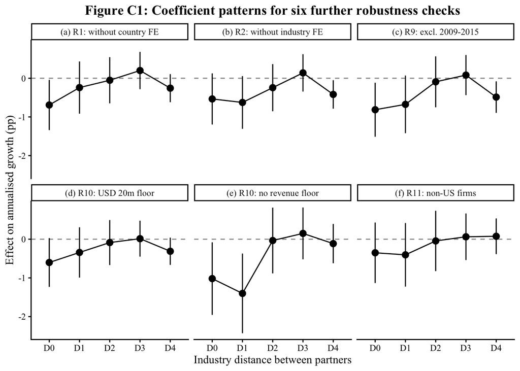

```r
coef_df <- function(m, label) {
  ct <- as.data.table(coeftable(m), keep.rownames = "term")[grepl("^log1p\\(d", term)]
  ct[, `:=`(category = factor(cat_labels_paper, levels = cat_labels_paper), check = label,
            est_pp = 100 * Estimate, lo = 100 * (Estimate - 1.96 * `Std. Error`),
            hi = 100 * (Estimate + 1.96 * `Std. Error`))]
  ct[, .(category, check, est_pp, lo, hi)]
}

panel_models <- list(`(a) R1: without country FE` = m_R1, `(b) R2: without industry FE` = m_R2,
                     `(c) R9: excl. 2009-2015` = m_R9, `(d) R10: USD 20m floor` = m_R10a,
                     `(e) R10: no revenue floor` = m_R10b, `(f) R11: non-US firms` = m_R11b)
panel_data <- rbindlist(Map(coef_df, panel_models, names(panel_models)))
panel_data[, check := factor(check, levels = names(panel_models))]

p_C1 <- ggplot(panel_data, aes(x = category, y = est_pp)) +
  geom_hline(yintercept = 0, linetype = "dashed", colour = "grey60") +
  geom_pointrange(aes(ymin = lo, ymax = hi)) +
  geom_line(aes(group = check)) +
  facet_wrap(~check, ncol = 3) +
  scale_x_discrete(labels = c("D0", "D1", "D2", "D3", "D4")) +
  labs(x = "Industry distance between partners", y = "Effect on annualised growth (pp)",
       title = "Figure C1: Coefficient patterns for six further robustness checks") +
  theme_thesis() + theme(axis.text.x = element_text(angle = 0))
p_C1
```

```r
ggsave(file.path(out, "fig_appx_C1_robustness_panels.png"), p_C1, width = 10, height = 6.5, dpi = 300)
```

## C2. R10 (no revenue floor), full size – the figure already referenced in section 5.1.1

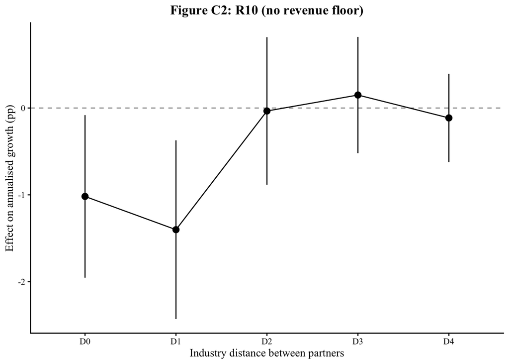

```r
p_C2 <- ggplot(coef_df(m_R10b, "R10: no revenue floor"), aes(x = category, y = est_pp, group = 1)) +
  geom_hline(yintercept = 0, linetype = "dashed", colour = "grey60") +
  geom_pointrange(aes(ymin = lo, ymax = hi)) + geom_line() +
  scale_x_discrete(labels = c("D0", "D1", "D2", "D3", "D4")) +
  labs(x = "Industry distance between partners", y = "Effect on annualised growth (pp)",
       title = "Figure C2: R10 (no revenue floor)") +
  theme_thesis()
p_C2
```

```r
ggsave(file.path(out, "fig_appx_C2_r10_no_floor.png"), p_C2, width = 5, height = 4, dpi = 300)
```

## Done

```r
cat("All appendix tables and figures written to:\n", out, "\n")
```

```
All appendix tables and figures written to:
 /Users/laramazzarelli/Desktop/Masterarbeit/Final Data/appendix_out_v2
```

```r
list.files(out)
```

```
 [1] "fig_appx_A1_country.png"
 [2] "fig_appx_A10_distance_by_year.png"
 [3] "fig_appx_A2_region.png"
 [4] "fig_appx_A6_panel_structure.png"
 [5] "fig_appx_A7_by_year.png"
 [6] "fig_appx_A8_revenue_floor.png"
 [7] "fig_appx_C1_robustness_panels.png"
 [8] "fig_appx_C2_r10_no_floor.png"
 [9] "table_appx_A1_country_full.csv"
[10] "table_appx_A1_country.csv"
[11] "table_appx_A10_distance_by_decade.csv"
[12] "table_appx_A2_region.csv"
[13] "table_appx_A3_us_split.csv"
[14] "table_appx_A4_size_split.csv"
[15] "table_appx_A5a_by_region.csv"
[16] "table_appx_A5b_by_size.csv"
[17] "table_appx_A6_panel_structure.csv"
[18] "table_appx_A7_by_year.csv"
[19] "table_appx_A8_revenue_floor.csv"
[20] "table_appx_A8b_revenue_bins.csv"
[21] "table_appx_A9_sic2.csv"
[22] "table_appx_B1_full_models.txt"
[23] "table_appx_B2a_robustness_R3_R4.txt"
[24] "table_appx_B2b_robustness_R7.txt"
[25] "table_appx_B2c_robustness_R8_R12.txt"
[26] "table_appx_B3_attrition.csv"
```